# FA22_virus_injections

Lorrie He

2022-09-13

## read me & changelog

this is the cleaned up code (from manduca.R) for analysing the growth/etc data for the virus injections :) see lab data dev/endpoint growth processing notes – basically i need to re-do the analysis for this to have it match up to the field stuff

### changelog

reverse chronological

1/25/22: * redoing round 4 plots –> make into bars for 1st committee mtg * copying from manduca.R * to-do: * fix file names LOL + add data into git repo * tbh i should put this into an R script. not an Rmd lol

9/25/22: * for now, work on the field analysis stuff before reworking the lab analysis. * working on field dev

## dushay + beckage data

notes * values were obtained from plot in the paper via some webapp lol

```r
testdata <- field_dev # create a test dataframe
```

```
Error: object 'field_dev' not found
```

```r
dnb <- read.csv("~/OneDrive - University of North Carolina at Chapel Hill/Y1/virus/db1993_data.csv")
names(dnb) <- sub("^X", "", names(dnb)) # removes leading X's in column names
```

# 230125 figs for 1st comm mtg

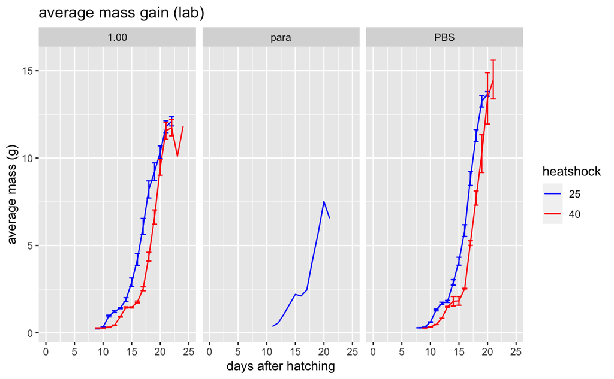

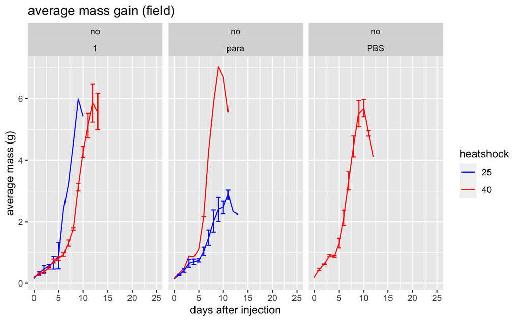

# 230125 PRE 1ST COMMITTEE MTG ERA

## lab data: development/endpoints

9/13/22 processing notes: * i should actually process this more like the field data… go redo this lol * currently set up to be analysed as date since 3rd instar – should be reworked to read by date since injection to better align with the field data

```r
## read in data & some pre-processing
all_lab <- read.csv("~/OneDrive - University of North Carolina at Chapel Hill/Y1/virus/mar2022.csv")
  # 9/13/22: this is the longform data. go read in the short form and convert to long

all_lab <- all_lab %>% filter(days.since.3rd <= 15) #the numbers look bad after 13 days tbh bc of all the drops in weight
lab_wands <- read.csv("~/OneDrive - University of North Carolina at Chapel Hill/Y1/virus/wands.csv")

# make columns numeric (they dont read in this way for some reason)
all_lab$weight.g <- as.numeric(all_lab$weight.g)

lab_wands$days.died <- as.numeric(lab_wands$days.died)
lab_wands$days.em <- as.numeric(lab_wands$days.em)
lab_wands$days.pup <- as.numeric(lab_wands$days.pup)
lab_wands$days.wand <- as.numeric(lab_wands$days.wand)
```

```r
# to remove the bad injections, slow growers, wandering nat. paras, pre-mature deaths (in injected/NP groups)

lab_clean <- all_lab %>% filter(unique != "R1-para.d0-03", unique != "R1-para.d0-05",
                            unique != "R1-para.d1-04",
                            unique != "R1-25-01", unique != "R1-25-02", unique != "R1-25-04", unique != "R1-25-09", unique != "R1-25-10",
                            unique != "R1-10-01", unique != "R1-10-02", unique != "R1-10-04", unique != "R1-10-07", unique != "R1-10-08", unique != "R1-10-09"  #keeping 10-10 in
                            ) %>%
                     filter((round == "R1" & treatment != "1") | round == "R2")


# 9/13/22 idk if i'll include those data subsets rn bc idk what i used them for LOL
#data.para <- data.rm2 %>% filter(unique != "R1-para.d0-03", unique != "R1-para.d0-05",
#                             unique != "R1-para.d1-04",
#                             treatment == "para")

#data.nopara <- data.rm2 %>% filter(treatment != "para")

#data.R1 <- data.rm2 %>% filter(round == "R1")

#data.R2 <- data.rm2 %>% filter(round == "R2")

#wands.nopara <- wands.rm %>% filter(treatment != "para")
#wands.para <- wands.rm %>% filter(treatment == "para")
```

```r
summary.rm2 <- data.rm2 %>% group_by(treatment, days.since.3rd) %>%
  summarise(avg = mean(weight.g, na.rm=TRUE),
            se = sd(weight.g, na.rm=TRUE)/length(weight.g),
            n = n())

summary.wands <- wands.nopara %>% group_by(treatment) %>%
  summarise(avg.wand.wt = mean(weight.wand, na.rm=TRUE),
            se.wand.wt = sd(weight.wand, na.rm=TRUE)/length(weight.wand),
            time.to.wand = days.wand-date.inj,
            avg.wand.time = mean(time.to.wand, na.rm=TRUE),
            se.wand.time = sd(time.to.wand, na.rm=TRUE)/length(time.to.wand),
            time.to.pup = days.pup-days.wand,
            avg.pup.time = mean(time.to.pup, na.rm=TRUE),
            se.pup.time = sd(time.to.pup, na.rm=TRUE)/length(time.to.pup),
            n = n())
```

```r
# whatever the hell this is

#all_orig <- read.csv("~/OneDrive - University of North Carolina at Chapel Hill/Y1/virus/all_devdata.csv")
  # how is this different from ~/.../virus/mar2022.csv?
```

## lab data: daily growth

```r
growth_trimmed <- read.csv("~/OneDrive - University of North Carolina at Chapel Hill/Y1/virus/daily.csv", header=T)
names(growth_trimmed) <- sub("^X", "", names(growth_trimmed)) # remove leading X's
```

## field data: endpoints only

```r
field_dev <- read_csv("~/Desktop/working_csvs/field_dev.csv")

testdata <- testdata %>%
  mutate(across(starts_with("mass.",), ~as.numeric(as.character(.))), # this one works
         across(starts_with("date.",), ~as.Date((.), format = "%d-%b")) # this doesnt tho lmfao
  )

## convert to julian dates

# something from indigo to try
# df %>%
#   mutate(
#     across(
#       .cols = date.inject:date.wander,
#       .fns = ~ as.numeric(as.Date(.x, format = '%d-%b'), format = '%j'),
#       .names = str_c('j', {.col}))

#field_dev$date.hatch <- as.Date(field_dev$date.hatch, format = "%d-%b")
#field_dev$j_date.hatch <- as.numeric(format(field_dev$hatch, "%j"))
#field_dev$date.4th <- as.Date(field_dev$date.4th, format = "%d-%b")
#field_dev$j_date.4th <- as.numeric(format(field_dev$date.4th, "%j"))
#field_dev$date.5th <- as.Date(field_dev$date.5th, format = "%d-%b")
#field_dev$j_date.5th <- as.numeric(format(field_dev$date.5th, "%j"))
#field_dev$date.6th <- as.Date(field_dev$date.6th, format = "%d-%b")
#field_dev$j_date.6th <- as.numeric(format(field_dev$date.6th, "%j"))
#field_dev$date.7th <- as.Date(field_dev$date.7th, format = "%d-%b")
#field_dev$j_date.7th <- as.numeric(format(field_dev$date.7th, "%j"))
field_dev$date.inject <- as.Date(field_dev$date.inject, format = "%d-%b")
field_dev$j_date.inject <- as.numeric(format(field_dev$inject, "%j"))
field_dev$date.pmd <- as.Date(field_dev$date.pmd, format = "%d-%b")
field_dev$j_date.pmd <- as.numeric(format(field_dev$date.pmd, "%j"))
field_dev$date.wander <- as.Date(field_dev$date.wander, format = "%d-%b")
field_dev$j_date.wander <- as.numeric(format(field_dev$date.wander, "%j"))
field_dev$date.pupa <- as.Date(field_dev$date.pupa, format = "%d-%b")
field_dev$j_date.pupa <- as.numeric(format(field_dev$date.pupa, "%j"))
field_dev$date.eclose <- as.Date(field_dev$date.eclose, format = "%d-%b")
field_dev$j_date.eclose <- as.numeric(format(field_dev$date.eclose, "%j"))

## doing stats
# stats_field.dev <- field_dev %>%      # this got wonky.. redoing this below
#     filter(species == "MS",
#          dose != "") %>%
#   group_by(temp, dose, is.sup) %>%
#   mutate(
#     time.towander = j_date.wander - j_date.inject,
#     time.topupate = j_date.pupa - j_date.inject,
#     time.toeclose = j_date.eclose - j_date.inject,
#     time.topmd = j_date.pmd - j_date.inject,
#     time.todeath = j_date.died - j_date.inject,
#   )

# avg masses and times to endpoints
endpoints_ms_field.dev <- field_dev %>%
  filter(species == "MS",               # filtering out "bad" individuals
         dose != "",
         source != "lab",
         is.na(ignore.reason)) %>%
  # mutate(                               # mutate adds onto new columns, summarise drops
  #   time.towander = j_date.wander - j_date.inject,
  #   time.topmd = j_date.pmd - j_date.inject) %>%
  group_by(temp, dose, is.sup) %>%
  dplyr::summarise(
    n = n(),
    avg_mass.wand = mean(mass.wander, na.rm=TRUE),
    avg_mass.pupa = mean(mass.pupa, na.rm=TRUE),
    avg_time.wand = mean(j_date.wander-j_date.inject),
    avg_time.pupa = mean(j_date.pupa-j_date.wander),
    avg_time.ec = mean(j_date.eclose-j_date.inject)
  )

# overview of individuals in expt (probably done!)
  # this would look nice as a stacked bar graph if i knew how to do that
  # consider when to separate MS and MQ...
overview_all_field.dev <- field_dev %>%
  filter(
    dose != "",
    species != "",
    source != "lab") %>%
  group_by(dose, temp, species) %>%
  dplyr::summarise(
    n = n(),
    n_pink = length(which(color == "pink")),
    n_pmd = length(which(outcome == "pmd")),
    n_wand = length(which(outcome == "wand")),
    n_wowe = length(which(outcome == "wowe")),
    n_em = length(which(outcome == "em")),
    n_sup = length(which(is.sup == "yes")),
    pct_pmd = format(round(n_pmd/n*100, 1), nsmall=1),
    pct_wand = format(round(n_wand/n*100, 1), nsmall=1),
    pct_sup = format(round(n_sup/n*100, 1), nsmall=1),
    pct_wowe = format(round(n_wowe/n*100,1), nsmall=1),
    pct_em = format(round(n_wowe/n*100,1), nsmall=1)
  )
```